# Trabajo Final Módulo Ciencia de Datos

Irene_Criado_Reyes

En primer lugar, cargaremos los datos en R, leyendo el fichero csv. Almacenamos el contenido del fichero en dataframe llamado churn_data

```r
# Código para lectura de datos
churn_data <- read.csv(file = "data/WA_Fn-UseC_-Telco-Customer-Churn.csv")

#Limpiamos los datos de NA
churn_data <- churn_data %>% drop_na(TotalCharges)
```

# Análisis Exploratorio

Lo realizaremos con el conjunto completo de datos: - Identifica para columna el tipo de dato (character, factor, numeric, etc) en el que ha sido almacenado

```r
#Utilizamos "str" para ver un resumen de la estructura de datos
str(churn_data)
```

```
## 'data.frame':    7032 obs. of  21 variables:
##  $ customerID      : chr  "7590-VHVEG" "5575-GNVDE" "3668-QPYBK" "7795-CFOCW" ...
##  $ gender          : chr  "Female" "Male" "Male" "Male" ...
##  $ SeniorCitizen   : int  0 0 0 0 0 0 0 0 0 0 ...
##  $ Partner         : chr  "Yes" "No" "No" "No" ...
##  $ Dependents      : chr  "No" "No" "No" "No" ...
##  $ tenure          : int  1 34 2 45 2 8 22 10 28 62 ...
##  $ PhoneService    : chr  "No" "Yes" "Yes" "No" ...
##  $ MultipleLines   : chr  "No phone service" "No" "No" "No phone service" ...
##  $ InternetService : chr  "DSL" "DSL" "DSL" "DSL" ...
##  $ OnlineSecurity  : chr  "No" "Yes" "Yes" "Yes" ...
##  $ OnlineBackup    : chr  "Yes" "No" "Yes" "No" ...
##  $ DeviceProtection: chr  "No" "Yes" "No" "Yes" ...
##  $ TechSupport     : chr  "No" "No" "No" "Yes" ...
##  $ StreamingTV     : chr  "No" "No" "No" "No" ...
##  $ StreamingMovies : chr  "No" "No" "No" "No" ...
##  $ Contract        : chr  "Month-to-month" "One year" "Month-to-month" "One year" ...
##  $ PaperlessBilling: chr  "Yes" "No" "Yes" "No" ...
##  $ PaymentMethod   : chr  "Electronic check" "Mailed check" "Mailed check" "Bank transfer (automatic)" ...
##  $ MonthlyCharges  : num  29.9 57 53.9 42.3 70.7 ...
##  $ TotalCharges    : num  29.9 1889.5 108.2 1840.8 151.7 ...
##  $ Churn           : chr  "No" "No" "Yes" "No" ...
```

- Visualiza un resumen del conjunto de datos mediante la función summary.

```r
# Utilazamos "summary" para obtener un resumen estadistico
summary(churn_data)
```

```
##   customerID           gender          SeniorCitizen      Partner           Dependents
##  Length:7032        Length:7032        Min.   :0.0000   Length:7032        Length:7032
##  Class :character   Class :character   1st Qu.:0.0000   Class :character   Class :character
##  Mode  :character   Mode  :character   Median :0.0000   Mode  :character   Mode  :character
##                                        Mean   :0.1624
##                                        3rd Qu.:0.0000
##                                        Max.   :1.0000
##      tenure      PhoneService       MultipleLines      InternetService    OnlineSecurity
##  Min.   : 1.00   Length:7032        Length:7032        Length:7032        Length:7032
##  1st Qu.: 9.00   Class :character   Class :character   Class :character   Class :character
##  Median :29.00   Mode  :character   Mode  :character   Mode  :character   Mode  :character
##  Mean   :32.42
##  3rd Qu.:55.00
##  Max.   :72.00
##  OnlineBackup       DeviceProtection   TechSupport        StreamingTV        StreamingMovies
##  Length:7032        Length:7032        Length:7032        Length:7032        Length:7032
##  Class :character   Class :character   Class :character   Class :character   Class :character
##  Mode  :character   Mode  :character   Mode  :character   Mode  :character   Mode  :character
##
##
##
##    Contract         PaperlessBilling   PaymentMethod      MonthlyCharges    TotalCharges
##  Length:7032        Length:7032        Length:7032        Min.   : 18.25   Min.   :  18.8
##  Class :character   Class :character   Class :character   1st Qu.: 35.59   1st Qu.: 401.4
##  Mode  :character   Mode  :character   Mode  :character   Median : 70.35   Median :1397.5
##                                                           Mean   : 64.80   Mean   :2283.3
##                                                           3rd Qu.: 89.86   3rd Qu.:3794.7
##                                                           Max.   :118.75   Max.   :8684.8
##     Churn
##  Length:7032
##  Class :character
##  Mode  :character
##
##
##
```

## Subsección 1

- De cara a la predicción del churn, para cada una de las variables excepto el customerID: o Realiza un diagrama de frecuencias para las variables cualitativas o histogramas para las variables cuantitativas.

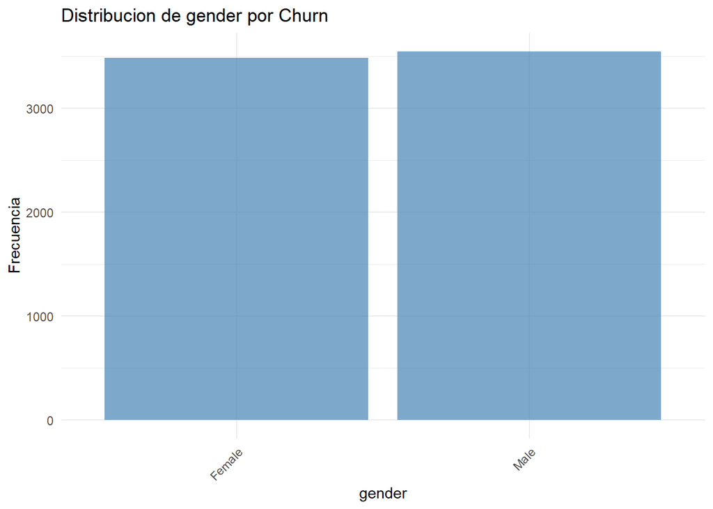

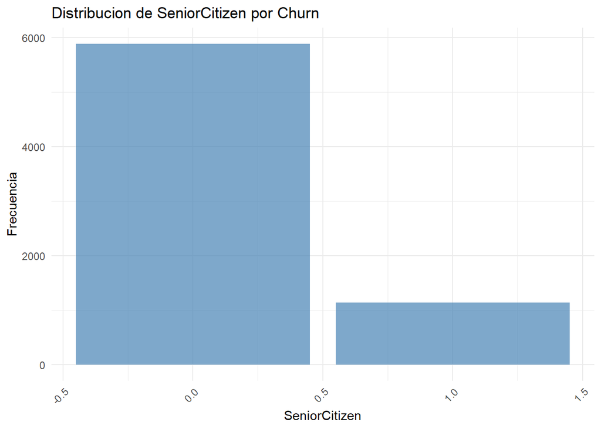

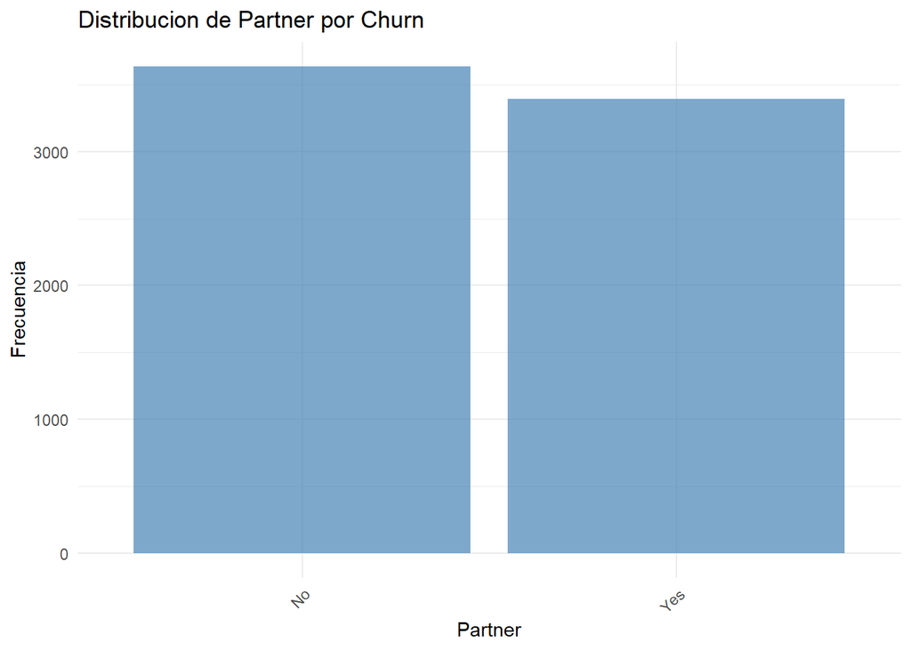

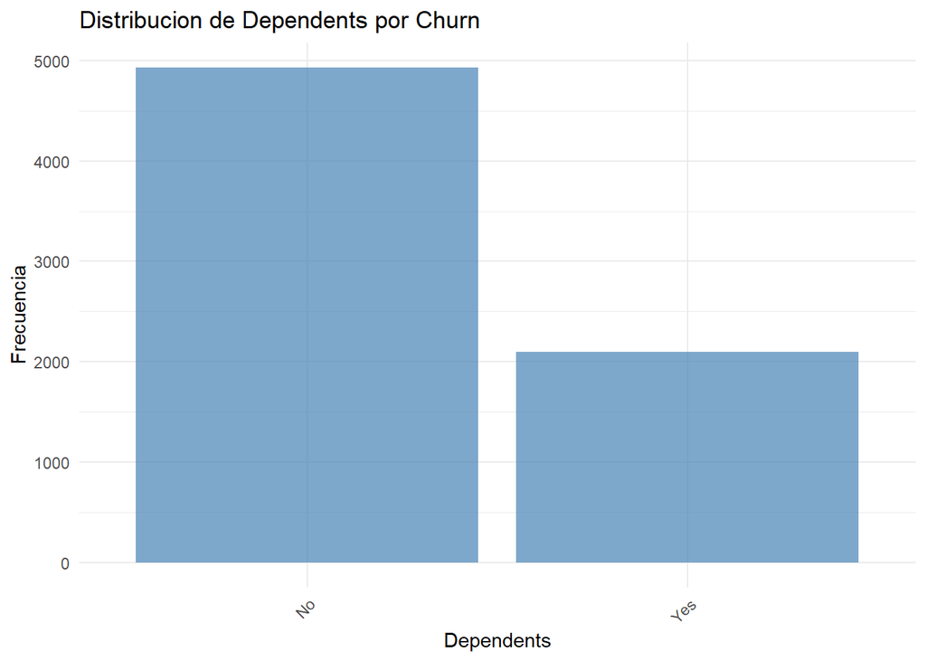

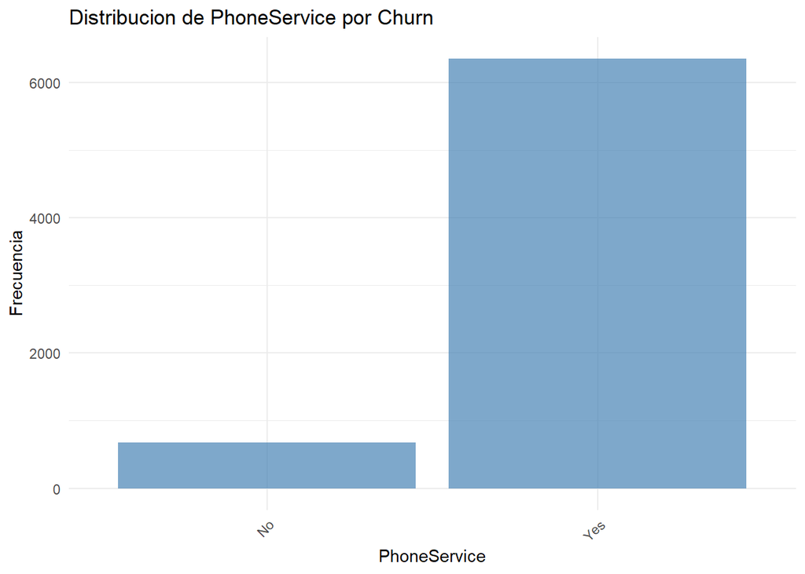

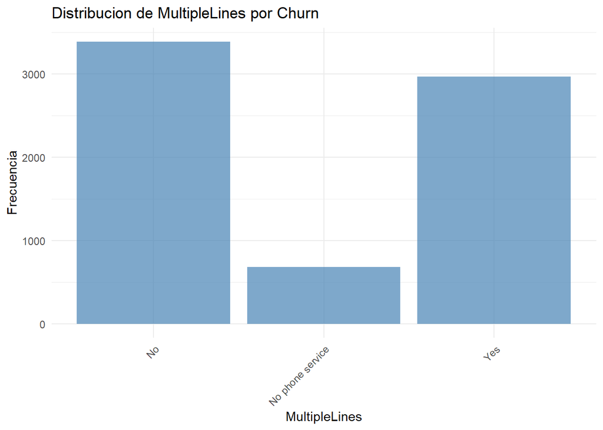

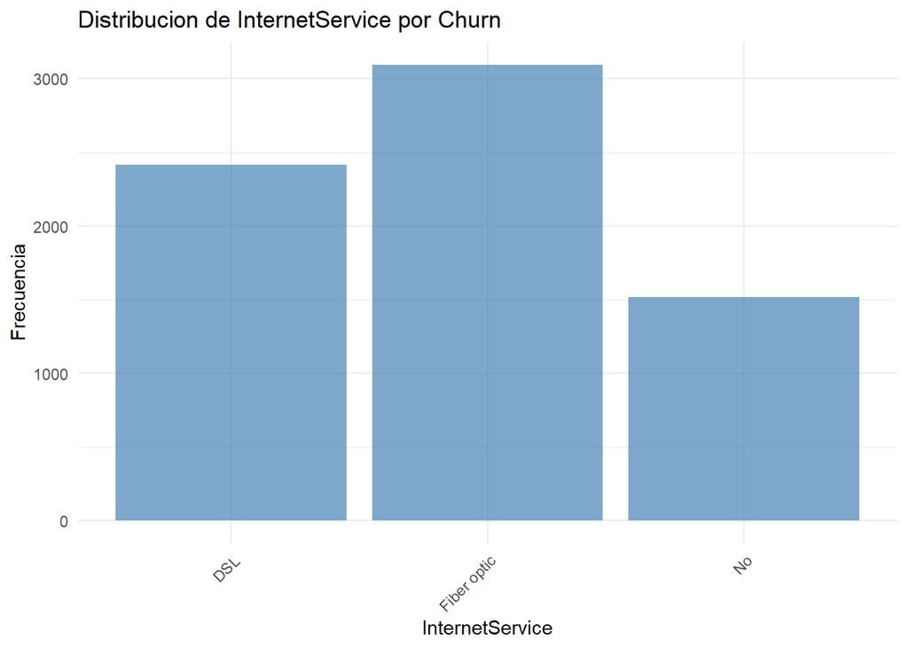

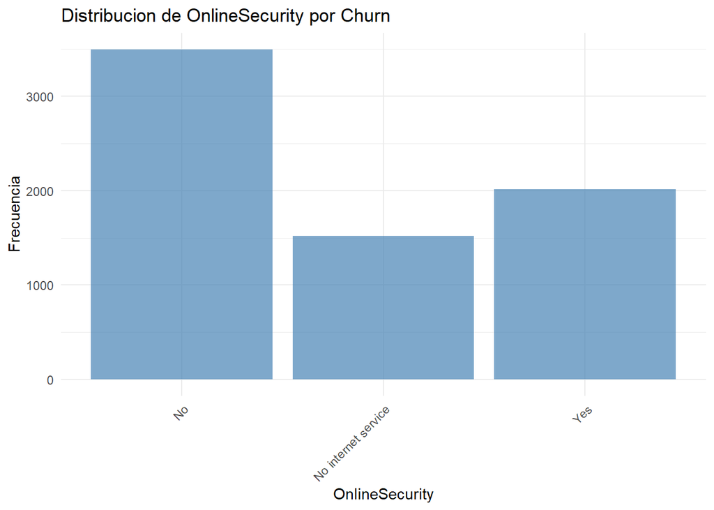

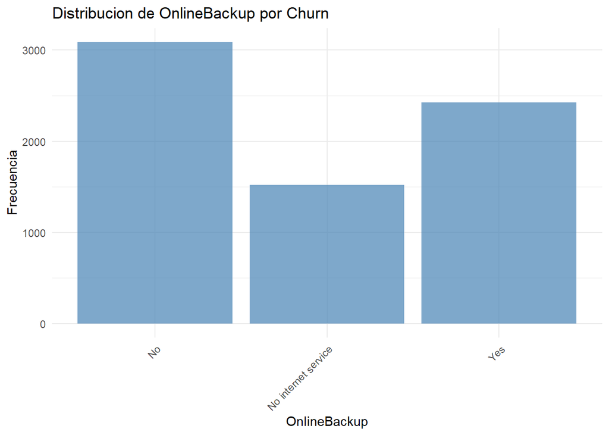

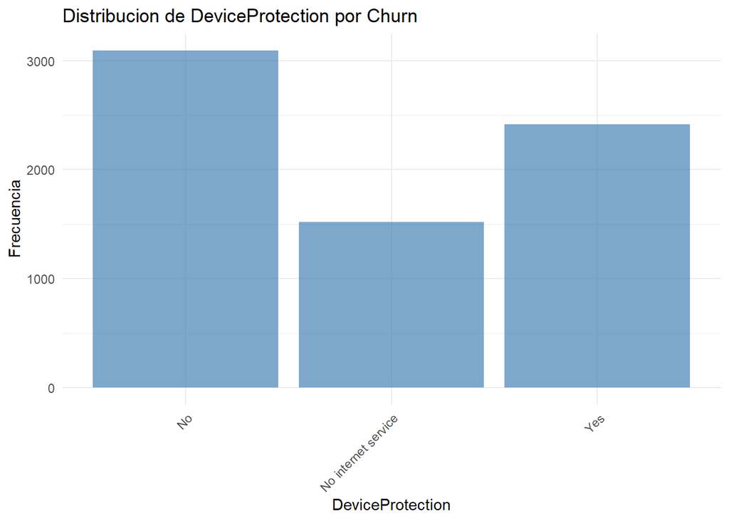

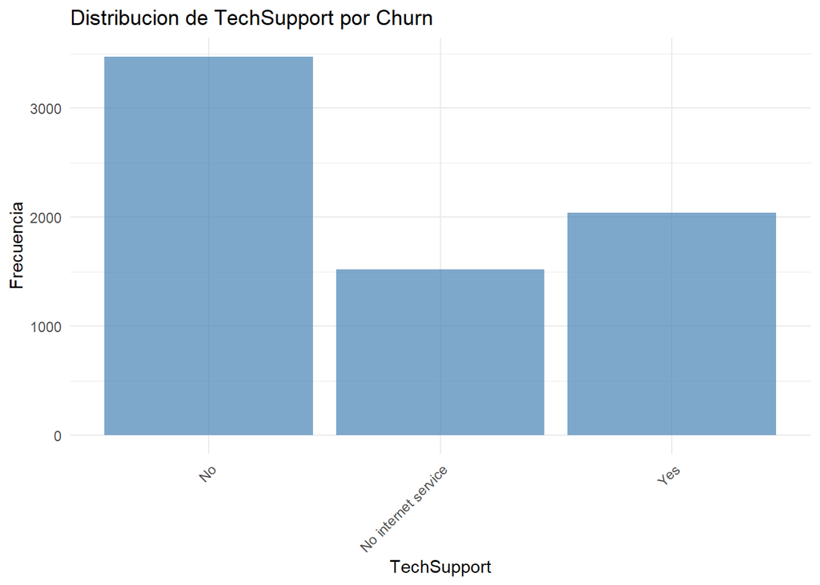

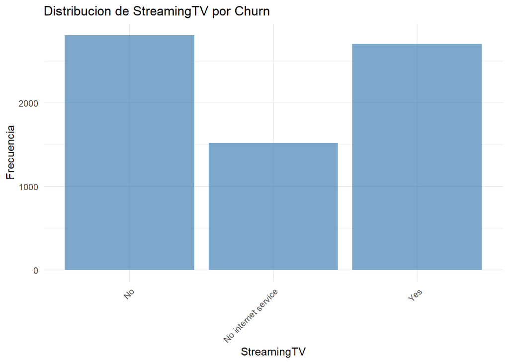

[4 more figures not shown]

```r
#Variables cualitativas menos "customerID"
cual <- c("gender", "SeniorCitizen", "Partner", "Dependents", "PhoneService",
              "MultipleLines", "InternetService", "OnlineSecurity", "OnlineBackup",
              "DeviceProtection", "TechSupport", "StreamingTV", "StreamingMovies",
              "Contract", "PaperlessBilling", "PaymentMethod")
#Grafico para las variables cualitativas
for (var in cual){
  cualitativas <- ggplot(churn_data, aes_string(x=var))+
    geom_bar(alpha=0.7, fill= "steelblue")+
    labs(title = paste("Distribucion de" , var, "por Churn"),
         x = var, y= "Frecuencia")+
     theme_minimal() +
    theme(axis.text.x = element_text(angle = 45, hjust = 1))
    print(cualitativas)
 }
```

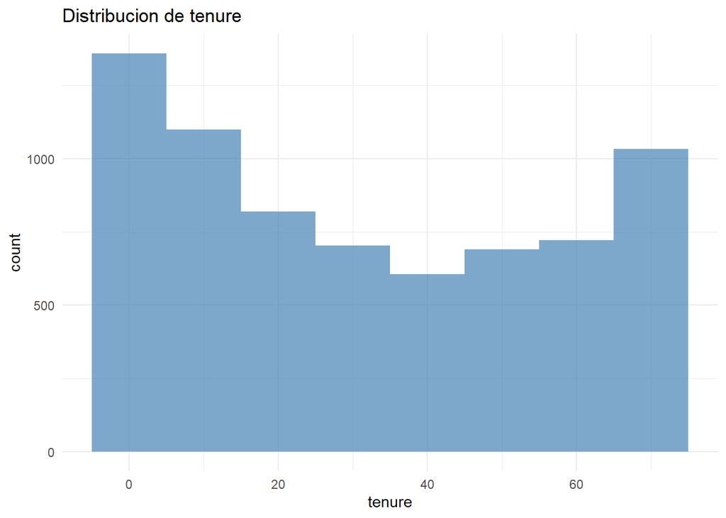

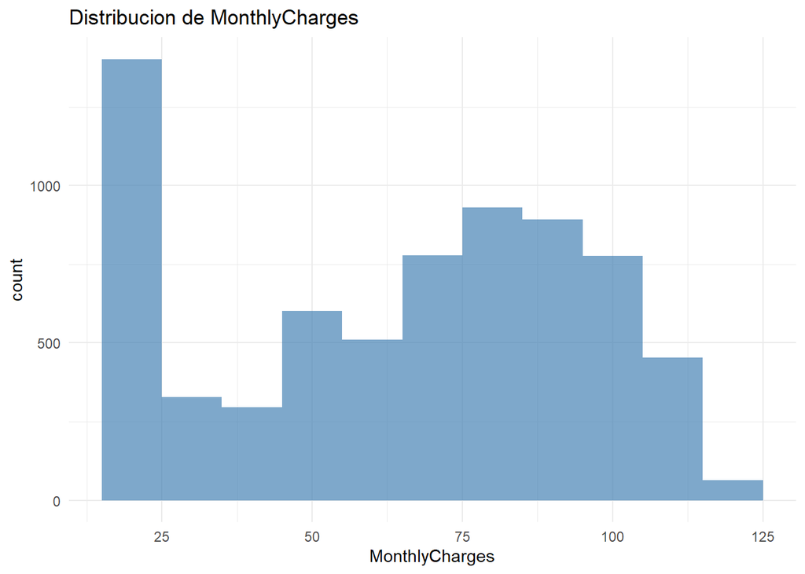

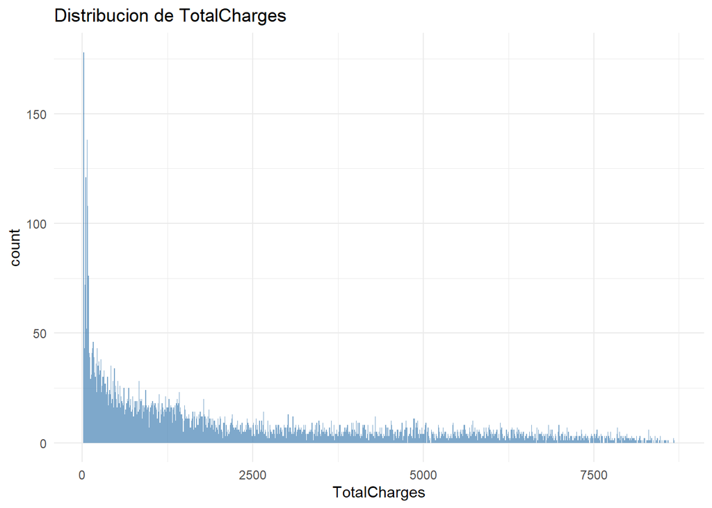

```r
#Variables cuantitativa
cuant <- c("tenure", "MonthlyCharges", "TotalCharges")

#Histogramas para cada variable cuantitativa
for (c in cuant) {
  cuantitativas <- ggplot(churn_data, aes_string(x=c))+
    geom_histogram(binwidth = 10, fill="steelblue", alpha=0.7)+
    labs(title= paste("Distribucion de", c))+
    theme_minimal()
  print(cuantitativas)
}
```

- Muestra los gráficos anteriores coloreados según la variable Churn para poder ver la proporción de “churners” en función del valor de las distintas variables. Se muestran dos ejemplos a continuación.

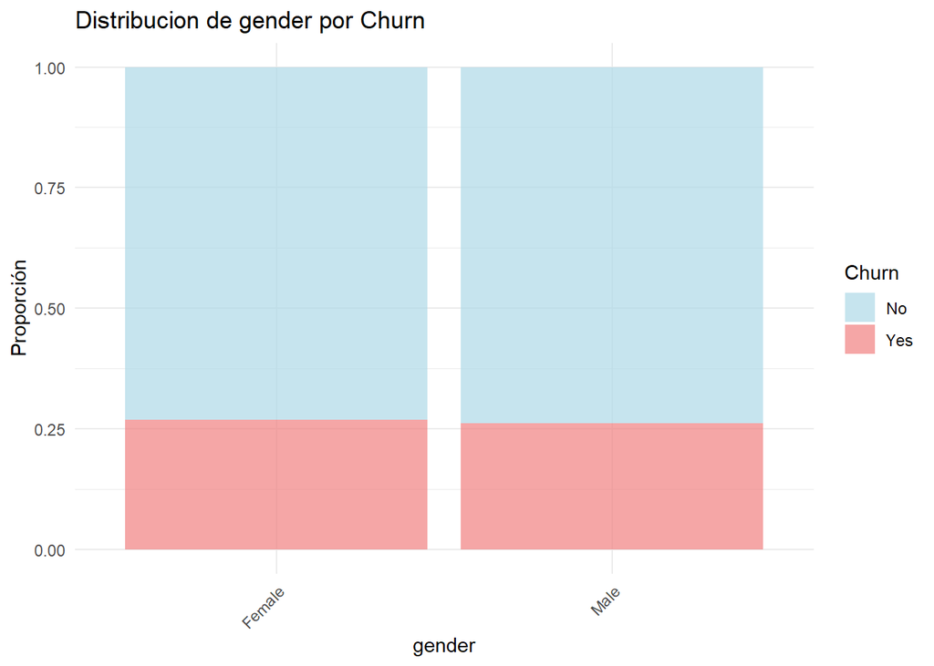

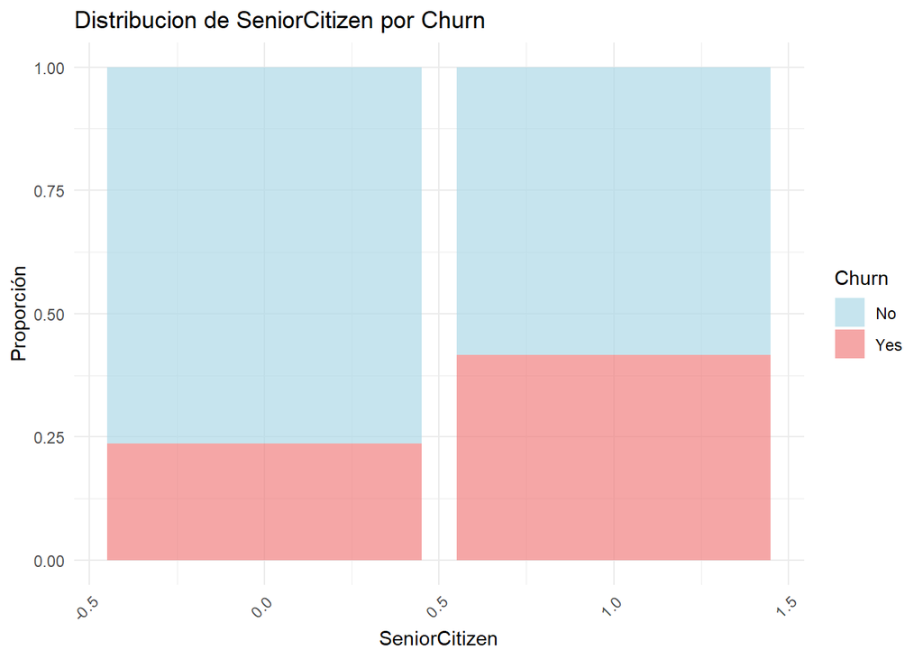

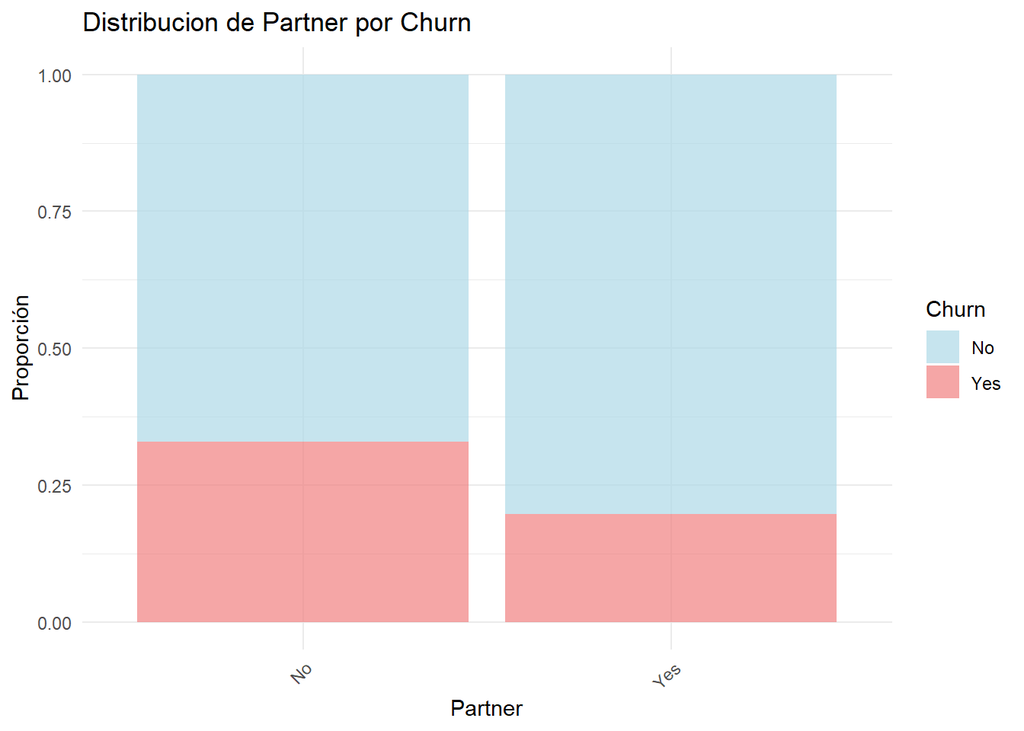

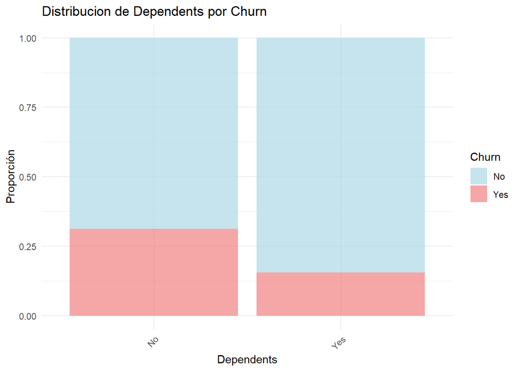

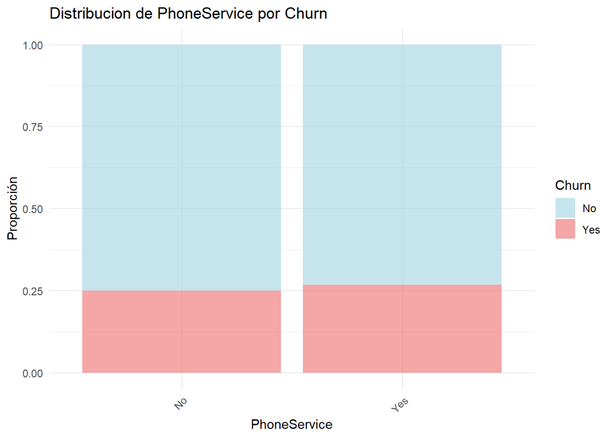

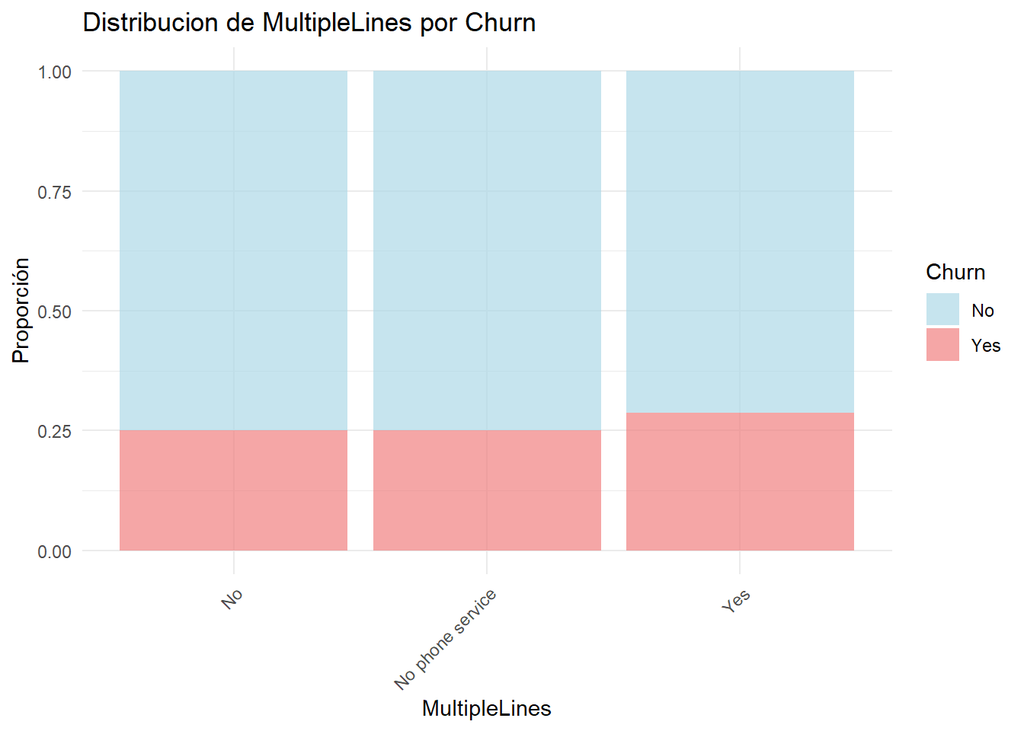

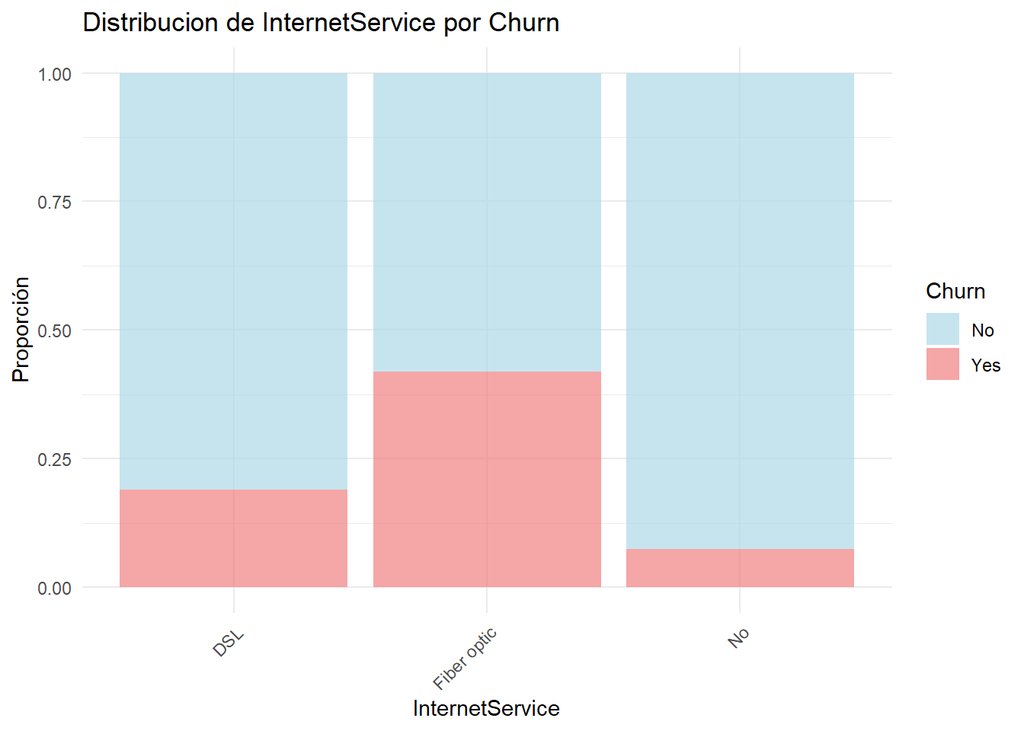

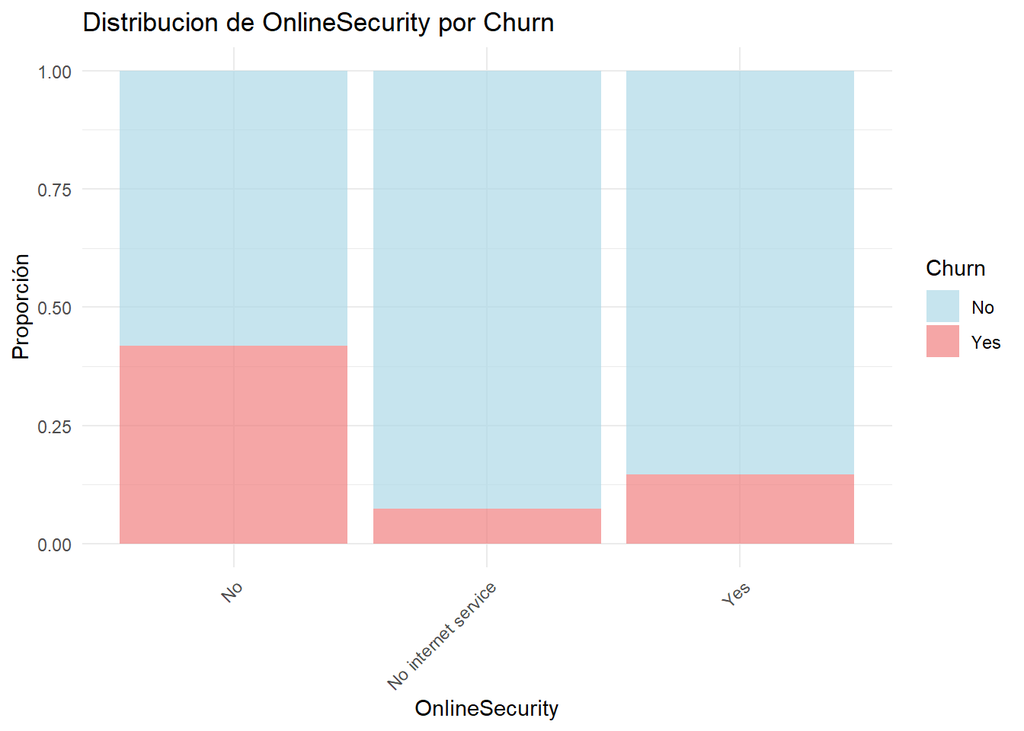

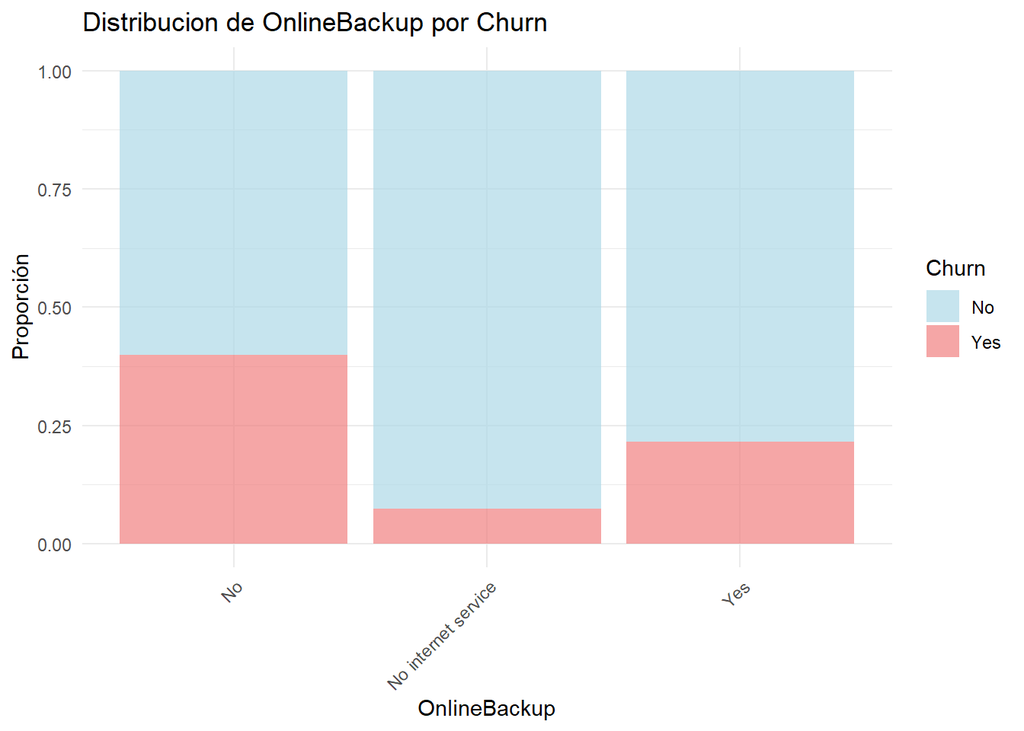

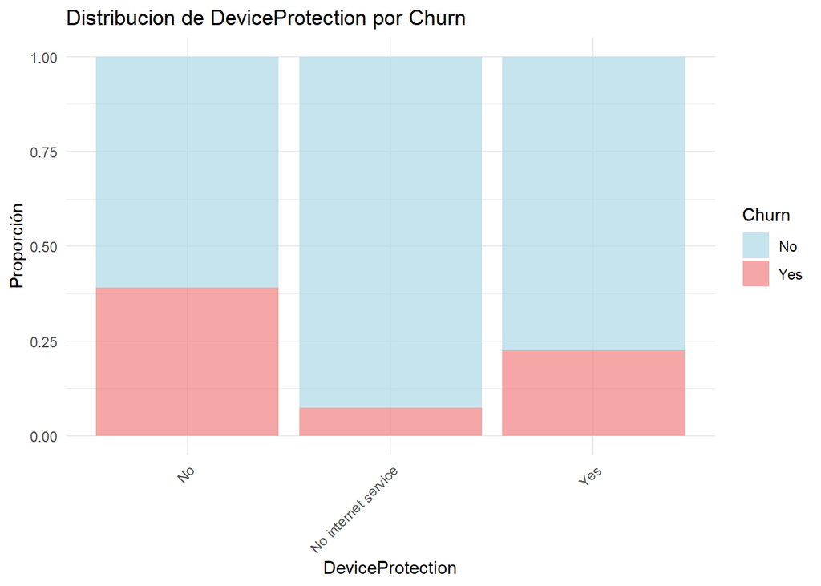

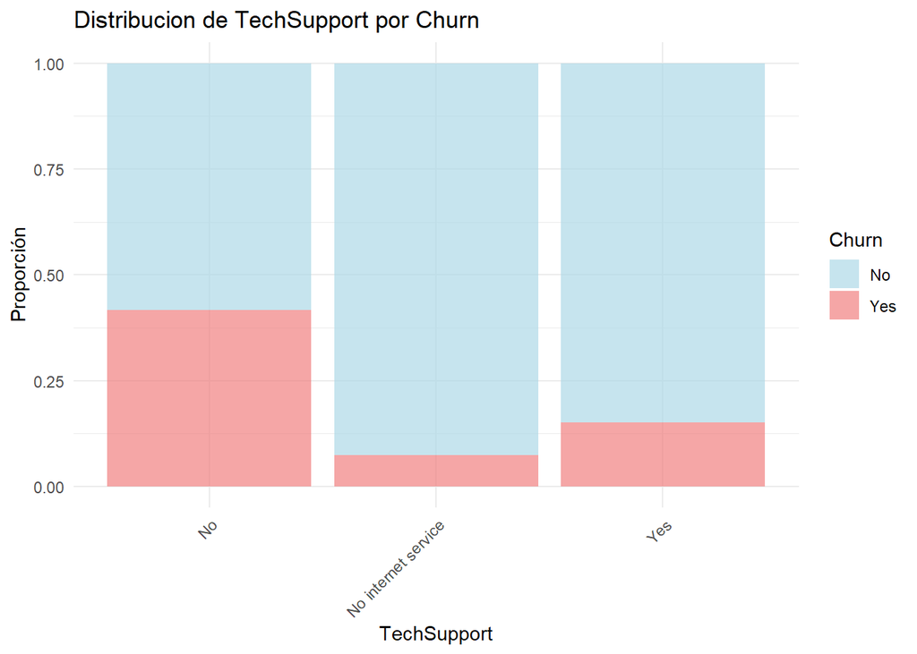

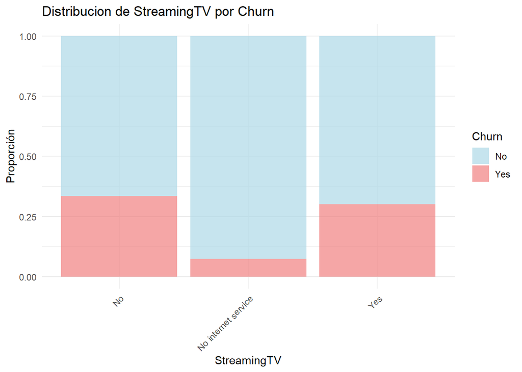

[4 more figures not shown]

```r
#Variables cualitativas menos "customerID"
cual_color <- c("gender", "SeniorCitizen", "Partner", "Dependents", "PhoneService",
              "MultipleLines", "InternetService", "OnlineSecurity", "OnlineBackup",
              "DeviceProtection", "TechSupport", "StreamingTV", "StreamingMovies",
              "Contract", "PaperlessBilling", "PaymentMethod")
#Grafico para las variables cualitativas
for (clc in cual_color){
  cl_color <- ggplot(churn_data, aes_string(x=clc, fill= "Churn"))+
    geom_bar(position = "fill", alpha=0.7)+
    labs(title = paste("Distribucion de" , clc, "por Churn"),
         x = clc, y= "Proporción")+
     theme_minimal() +
    theme(axis.text.x = element_text(angle = 45, hjust = 1)) +
    scale_fill_manual(values = c("No" = "lightblue", "Yes" = "lightcoral"))
    print(cl_color)
 }
```

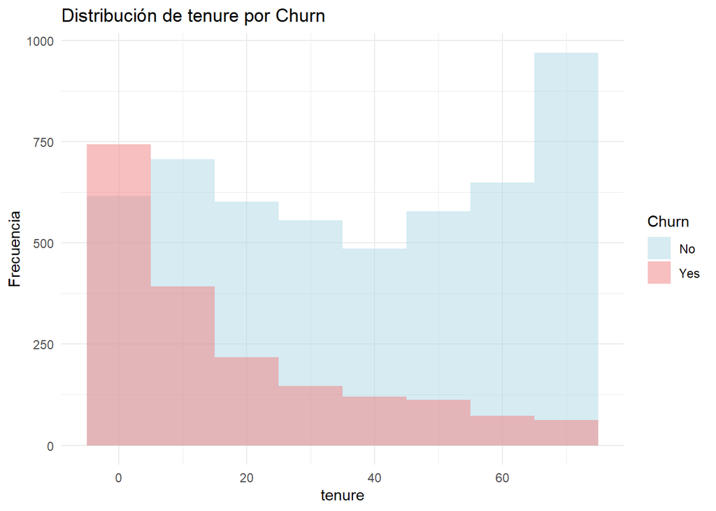

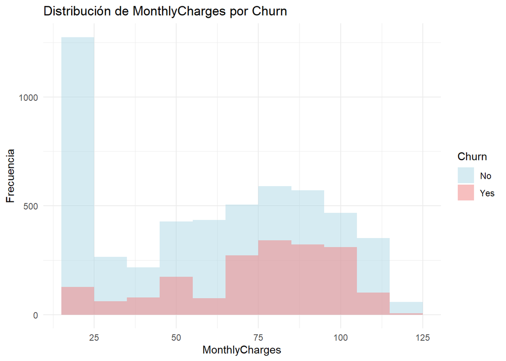

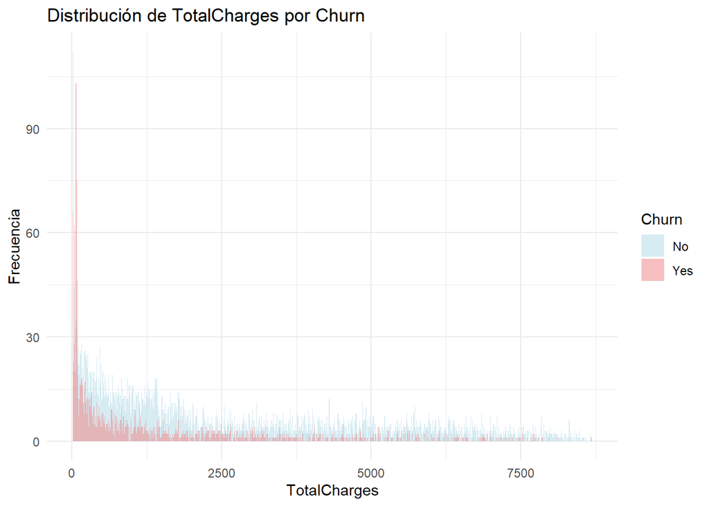

```r
#Variables cuantitativas
cuant_color <- c("tenure", "MonthlyCharges", "TotalCharges")

#Histograma para cada variable cuantitativa
for (var in cuant_color) {
  ct_color <- ggplot(churn_data, aes_string(x = var, fill = "Churn")) +
    geom_histogram(binwidth = 10, position = "identity", alpha = 0.5) +  # Ajustar binwidth según sea necesario
    labs(title = paste("Distribución de", var, "por Churn"),
         x = var, y = "Frecuencia") +
    theme_minimal() +
    scale_fill_manual(values = c("No" = "lightblue", "Yes" = "lightcoral"))

  print(ct_color)
}
```

## Subsección 2

- De cara a la predicción del gasto mensual:
  - Para las variables categóricas realiza un boxplot que muestre la distribución del gasto mensual (MonthlyCharges) para cada valor de las variables